# Final Project Story

Arjun

2023-12-09

**Introduction**  
Have you ever wondered why students are the biggest group of consumers of caffeine? It’s more than just a habit, especially during exams where the environment of the academic stress and workload is more intense than ever. We’ve all been there, the sleepless nights, the pressure, the need for an extra kick to power through. That’s why we’ve chosen students as our focus. They are the biggest consumers of caffeine. For this project our intended audience encompasses a big range of students. Those interested in utilizing the dataset are from a range of staff. professors, and school administrators seeking to develop a deeper understanding of the impact of caffeine on students’ focus in both school and the classroom and to get better educated on the entire project. The datasets we cover are on the general effects of caffeine on students. The information was gathered through research and surveys conducted by students across various school and university campuses. From the research we found it included the side effects of caffeine on students, the different types of caffeine, effects on sleep and sleep schedule, etc. Especially in an area like Seattle, coffee is everywhere you turn, and the cafes are endless. Looking over all of this, we wanted to be able to dive deeper on the effects of caffeine and the side effects on students specifically and how to help maintain it.  
With students constantly navigating academic stress and heavy workloads, many turn to caffeine as a coping mechanism. We chose this specific topic as we felt like it was a very relatable topic for many people, especially with us being students who are also going through this same issue of caffeine. As we have seen and interacted with many people and communities on UW campus, we can empathize with the role caffeine plays in their lives, and also the amount of data from many other schools with the same topic. Our target audience is mostly focused on students and the datasets we are working with focus on understanding the general impact of caffeine on students. Data collection is made through research and surveys conducted across various school and university campuses. Despite widespread awareness of these side effects, individuals continue to willingly subject their bodies to caffeine. Our objective is to go into detail into the side effects of caffeine and ways to help manage and maintain that as a student. Ultimately, through this project and research, we aim to provide a deeper insight into the consequences of excessive caffeine consumption among students. We hope to offer recommendations for managing or limiting caffeine usage in a healthy manner, recognizing the importance of balancing academic demands as well as with overall well-being.  
**Explain your Data**  
We decided to use these datasets, as it was a confirmed study on the effects of caffeine across over 100 students. There was various data presented in the study, which made it easier to find the topics/correct data we needed to answer our question. The various data included data on the backgrounds of each student, the amount of caffeine consumed, the time of day it was consumed, and the resulting effects of caffeine. With a wide range of data, we were able to evaluate the data that was relevant to our research, and merge it into one dataset to show our trends.  
Our datasets originated from a cross-sectional study that was conducted in the UAE from December 2019 to March 2020. The study observed 500 students from different universities in the UAE. The data was studied and organized by students at the Al Ain University, under the guidance of Dr. Azza Ramadan. The data is freely available for everyone to look at, and sampling is fine as long as there is credit and it is for non-commercial purposes. In order to access the complete, raw, dataset, one needs to request permission from the researchers by directly contacting them.  
The datasets are about every aspect of students’ caffeine consumption and the effects of their consumption. There are multiple datasets just regarding the background/demographic of the various test participants. There were also various datasets that summarized the nature of the experiments, such as how much caffeine was taken, when, and why, as well as the resulting side effects.  
The datasets are about the consumption of caffeine amongst University students. The population of this experiment are University students who drink caffeine. The data only encompasses 500 cases of such individuals, which is a very small sample in the overall picture. Though the 500 individuals are all from different backgrounds and physical stature, it is important to note that the data may still be skewed or biased due to the lack of the region– all 500 students were from different schools that were all in the UAE. Therefore the data may have more validity in reference to the region compared to globally. Also, the proportionately small data sample compared to the overall population may lead to misrepresentation. It’s crucial to question whether it is fair for the research to generalize the effects of caffeine on university students based on the small sample size they studied.  
Overall, the data quality wasn’t bad in terms of just the individual presentations. However, each data set was formatted differently, and the basis for each data was different as well. In some data charts, each row would be a type of effect, with the numbers as students, while in others, each row is a specific case of each student. This made it difficult to sort out and determine which data was actually relevant to answering our main research question. It was difficult to find what the purpose of each individual data set was, as well as differentiate between the sets. This added confusion and inconsistency in data did cause some issues in reshaping and organizing the data to make it more relevant to us.  
The rows in our final data set represent the amount of differing types of coffee that participants in the study consume. It also shows their age and then percentage that consume each type of coffee. data set has 33 rows, 8 columns. The relevant variables are “Unit”, “Variable”, “Total”, “Age”, “Participants”, “Caffeine Consumption”, and “percent_50”. They are coded in as columns and the “missing values” in the “Total” column are coded in as 0.

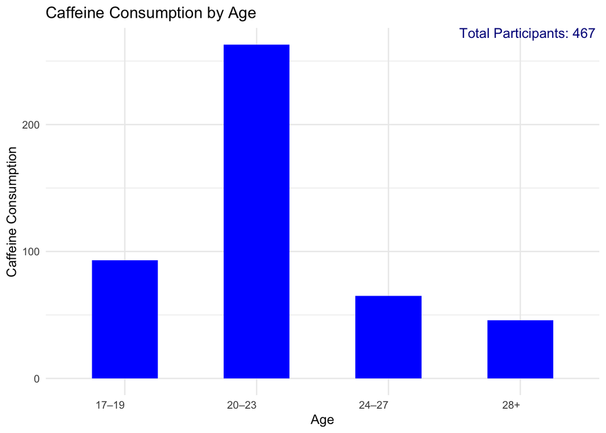